# Social Network Analysis Homework 7

Roles & Communities.

Yifan Li (Department of Sociology, UMass Amherst)  
2022-03-23

##**Description of Game of Throne marriage network.**

```
 Network attributes:
  vertices = 18
  directed = FALSE
  hyper = FALSE
  loops = TRUE
  multiple = FALSE
  bipartite = FALSE
  total edges= 61
    missing edges= 0
    non-missing edges= 61

 Vertex attribute names:
    color region vertex.names

 Edge attribute names:
    weight
```

```
[1] 0.3267974
```

```
[1] 0.3787375
```

```
[1] 1
```

```
   Min. 1st Qu.  Median    Mean 3rd Qu.    Max.
   1.00    1.00    2.00    3.59    4.00   17.00
```

Since blockmodel works better with small network, I use the Game of Throne marriage network (instead of the huge world trade network) for homework 6 & 7.

This network is a undirected network showing the marriage between important families in Westeros. (I think if we distinguish which family the bride and groom belong to in each marriage, we can also create a directed network. I may try it later.) Each node represents a family (or a set of less important families of one region), while each tie indicates there are one or more marriage between the two families. The weights represents how many marriages have occurred between the family. There is only one component in this network, indicating all the important Westeros ruling families are connected by marriage.

##**Roles & blockmodels.**

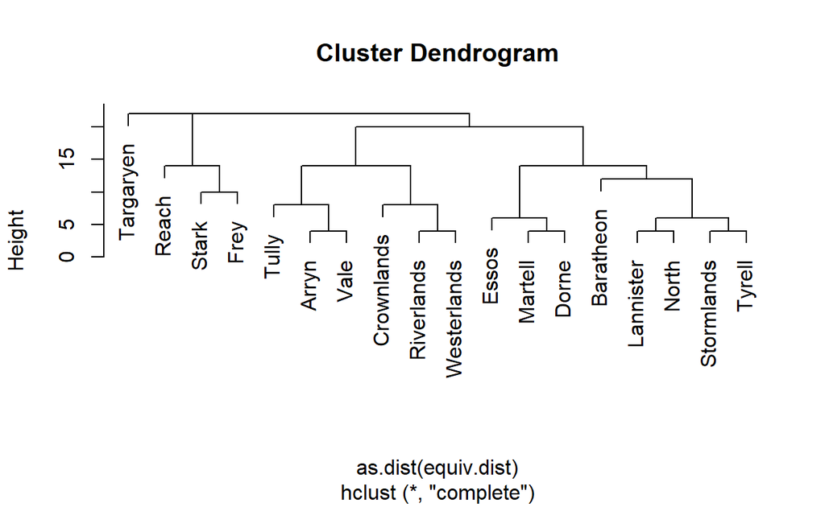

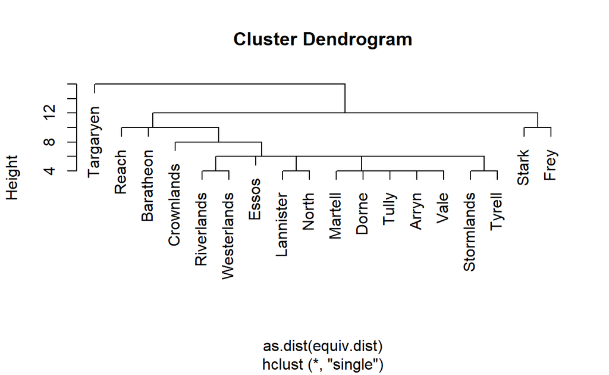

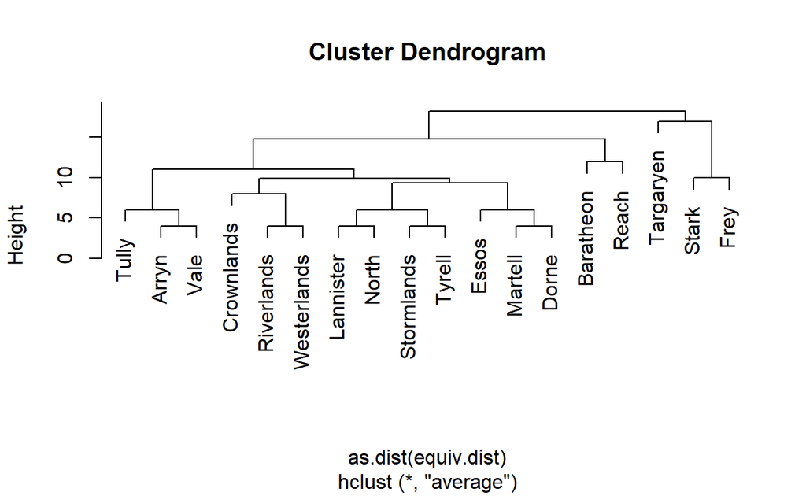

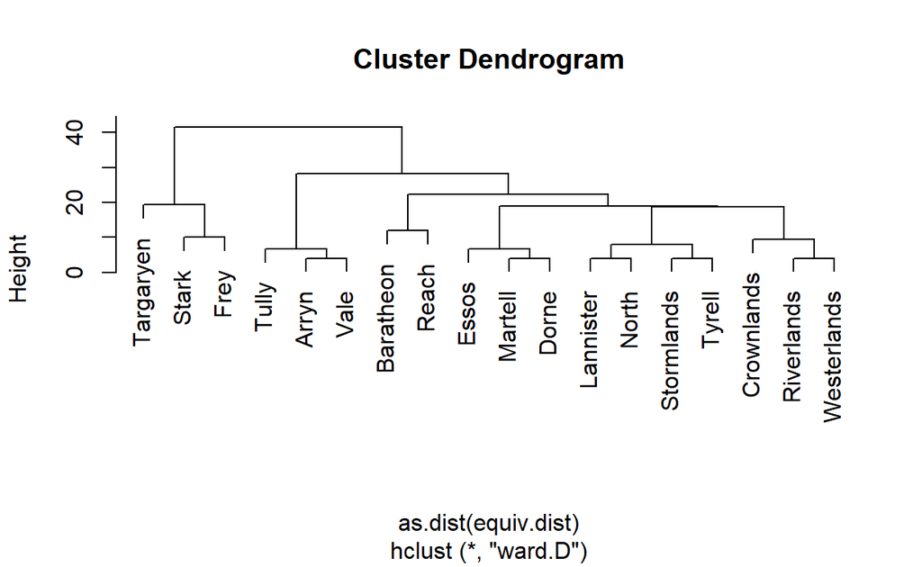

Except for using single clustering method, the three other methods give a clear hierarchical structures which capture differences in network position between the families. All the four method identify Targaryen as an unique role to some extent, which is bery reasonable due to its status in the book.

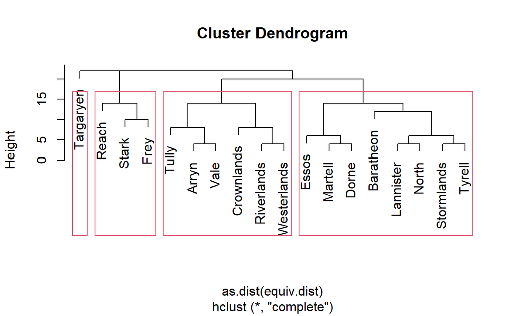

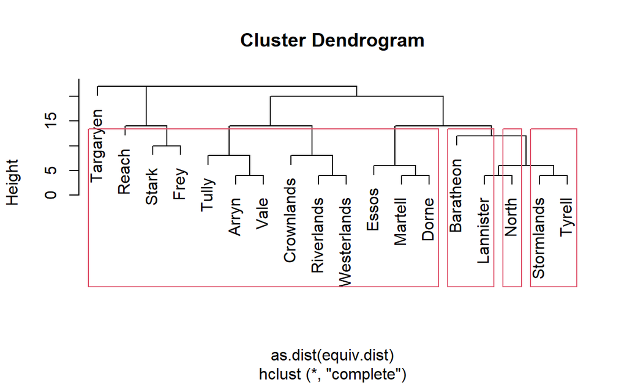

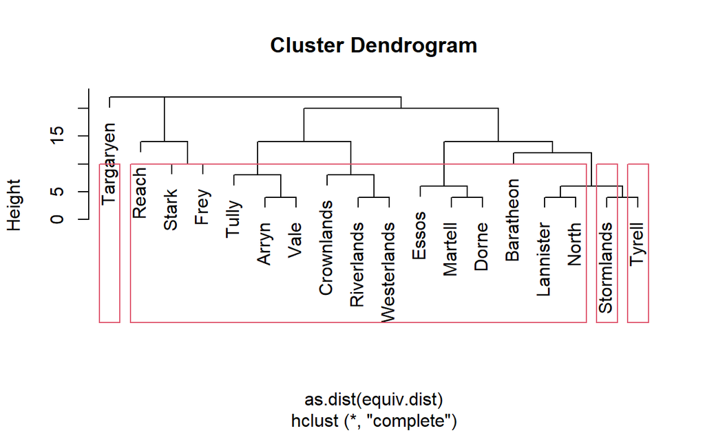

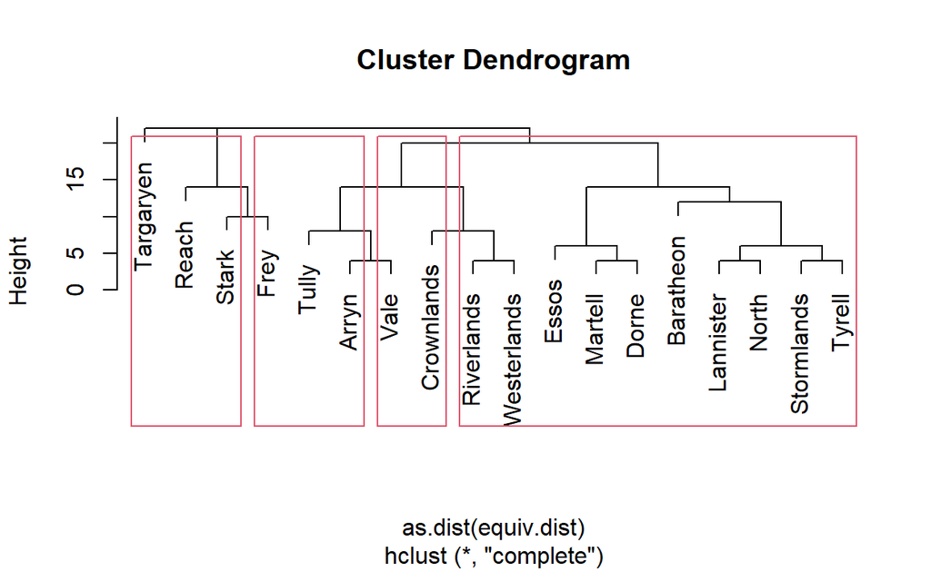

For me, it’s a little confusing what these red rectangles mean. The partition is crossing the branches. The role values assigned by blockmodels are also different from the division in those plots. So I will focus more on the blocks partitioned by the blockmodels, and use the cluster dendrograms just as visual reference.

```
           Block 1    Block 2   Block 3   Block 4
Block 1 0.40000000 0.04166667 0.6666667 0.8333333
Block 2 0.04166667 0.17857143 0.5000000 0.6250000
Block 3 0.66666667 0.50000000 0.3333333 0.6666667
Block 4 0.83333333 0.62500000 0.6666667       NaN
```

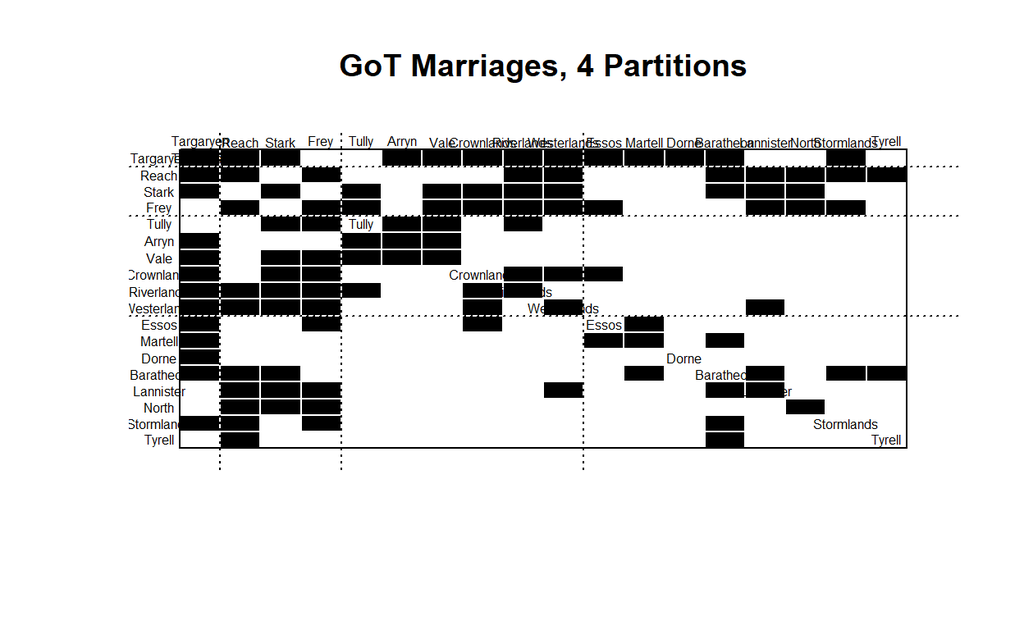

```
          Block 1   Block 2   Block 3   Block 4
Block 1 0.1153846 0.3846154 0.6153846 0.6923077
Block 2 0.3846154 1.0000000 0.5000000 1.0000000
Block 3 0.6153846 0.5000000 0.0000000 0.5000000
Block 4 0.6923077 1.0000000 0.5000000       NaN
```

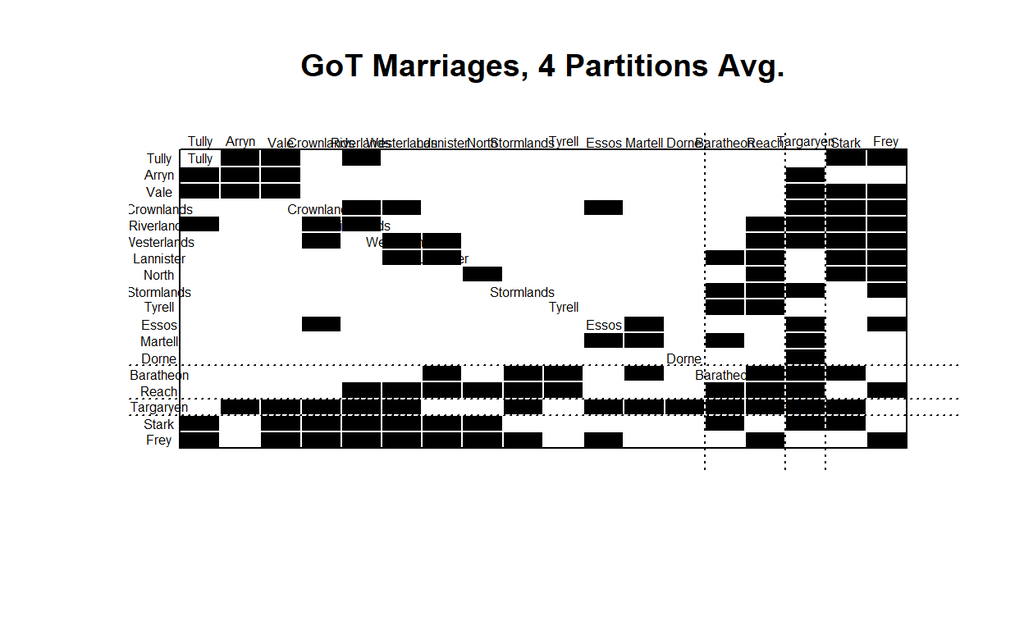

```
          Block 1   Block 2   Block 3   Block 4
Block 1 0.1904762 0.5333333 0.6666667 0.7333333
Block 2 0.5333333       NaN 0.0000000 1.0000000
Block 3 0.6666667 0.0000000       NaN 0.0000000
Block 4 0.7333333 1.0000000 0.0000000       NaN
```

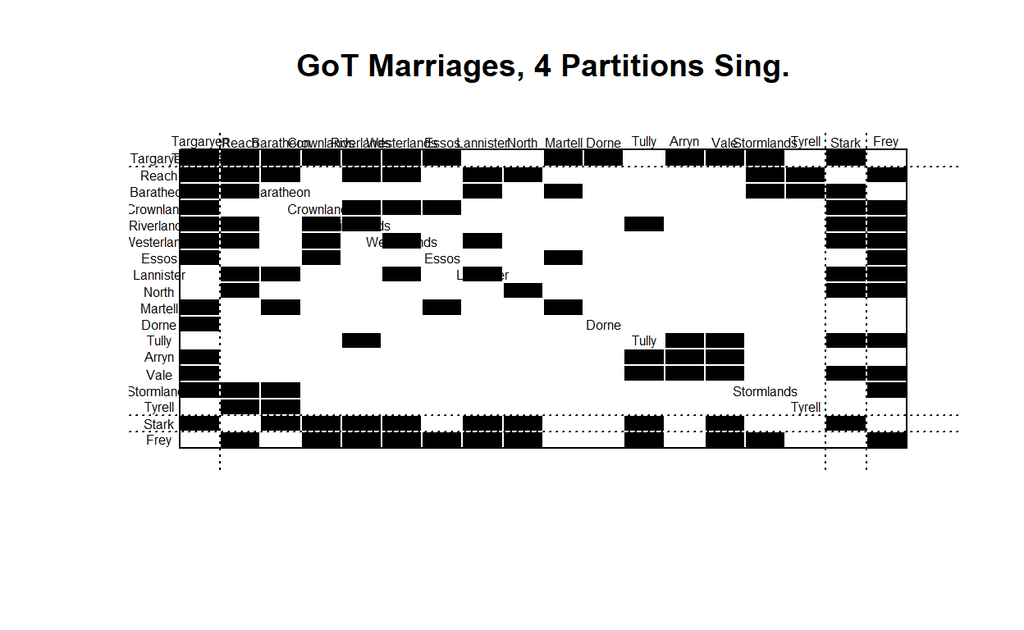

```
           Block 1   Block 2    Block 3   Block 4
Block 1 1.00000000 0.0000000 0.03333333 0.6666667
Block 2 0.00000000 1.0000000 0.50000000 0.6666667
Block 3 0.03333333 0.5000000 0.11111111 0.6333333
Block 4 0.66666667 0.6666667 0.63333333 0.3333333
```

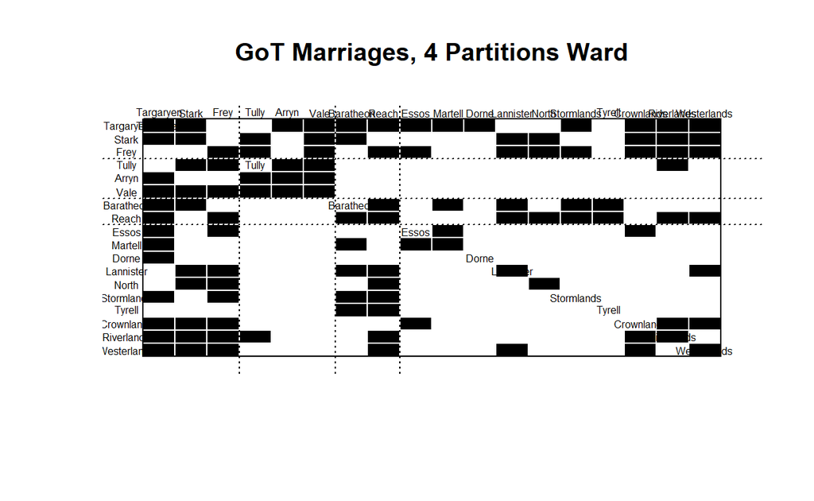

Again, the single clustering method makes the least sense. 3 families get one block for each, and the others are all in the same block.

Among the other three, the Ward D method give the most 0s and 1s (or near 0 or 1). It seems to best capture differences in network position between the families. Let’s explore it further.

```
           Block 1   Block 2    Block 3   Block 4
Block 1 1.00000000 0.0000000 0.03333333 0.6666667
Block 2 0.00000000 1.0000000 0.50000000 0.6666667
Block 3 0.03333333 0.5000000 0.11111111 0.6333333
Block 4 0.66666667 0.6666667 0.63333333 0.3333333
```

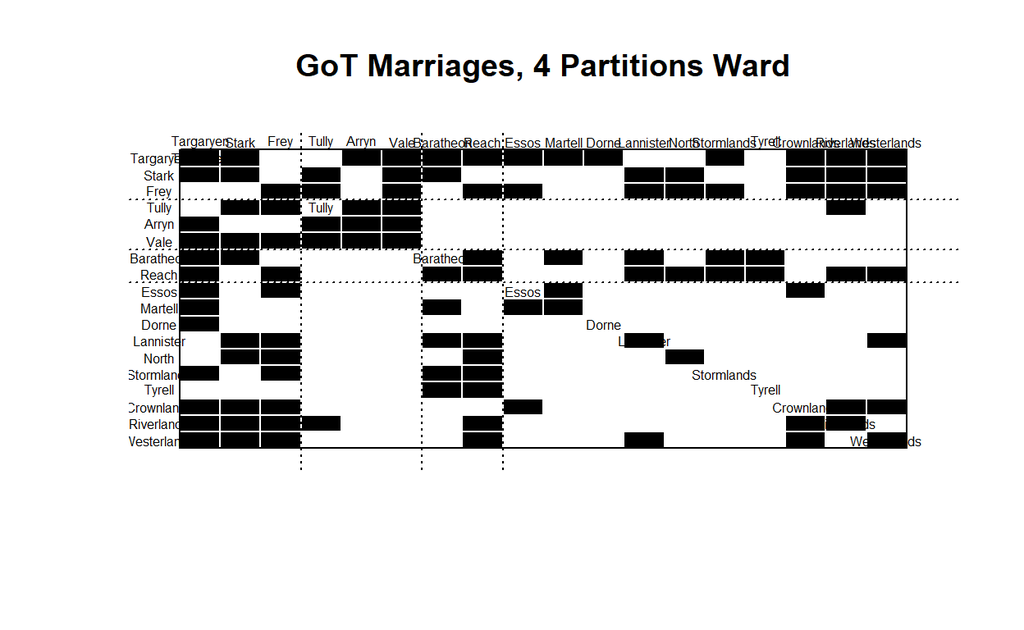

```
          name role_wrd
1        Arryn        1
2        Tully        1
3         Vale        1
4    Baratheon        2
5        Reach        2
6    Lannister        3
7      Martell        3
8   Stormlands        3
9       Tyrell        3
10  Crownlands        3
11       Essos        3
12  Riverlands        3
13 Westerlands        3
14       North        3
15       Dorne        3
16       Stark        4
17        Frey        4
18   Targaryen        4
```

Block 1(Arryn, Tully, and Vale) and Block 2 (Baratheon and Reach) show a faction pattern. They are fully connected to each other within factions by marriage ties while have no marriage with the other faction. It’s understandable since the Arryn family rule the Vale, so they have close relation to nobles of the Vale. The Tully family rule the riverlands, which is next the Vale. And this part of Westoros has few connections to Baratheons and nobles in Reach. (Not quite sure why the Baratheon and the Reach are viewed as the same role and a faction. Maybe I’m not familiar enough with the book.)

Block 3 consists of most other families. They are loosely connected to each other. The block 1 or faction of Vale and Riverlands has very limited connections with block 3, indicating that they are not deeply involved in other affairs in Westeros. The Baratheon block have some relation with them, which might provide the support for the throne. Sadly, this connection is not enough. Perhaps this is one of the causes of the War of the Five Kings.

Block 4 (Targaryen, Stark and Frey) is loosely self connected, but have a relative high connection to all the other 3 blocks. It is quite interesting since these there families (especially the Targaryen and the Stark) are the central families to the story of the book. The three families have extensive and similar political resources in Westeros. They marry each other and compete with each other at the same time. The most important marriages in the story take place between these three families. Meanwhile, House Stark’s war to help Baratheon against Targaryen, and Frey’s betrayal of Stark, are two of the most significant turning points in Westeros history. The role analysis shows us they fight each other because they occupy similar roles.

Interestingly, one of the other major family for the book, the Lannister has no unique roles in all four methods. This fact might help explain why the Lannisters try to grasp the power and make many political enemies on the one hand, and struggling so much in the process on the other hand.

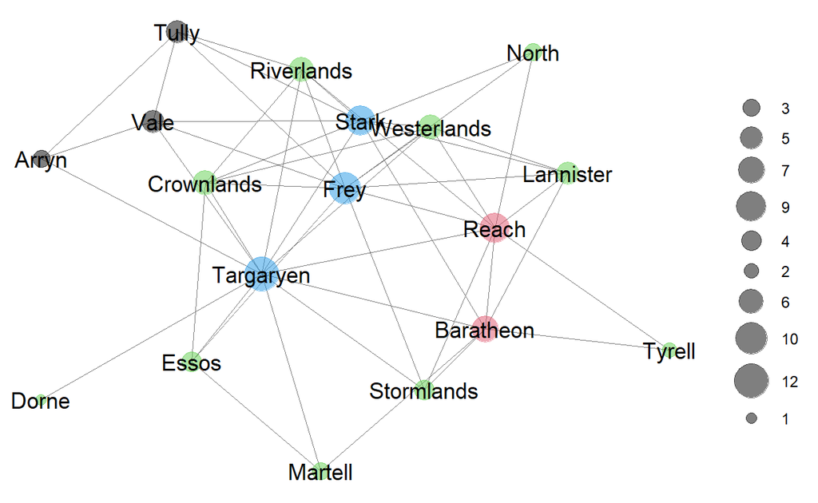

The plot show the pattern more clearly. The Stark, Frey and Targaryen sit in the center of the network and compete with each other. Baratheon and Reach sit near the center. Other families are surrounding around the core five, while Tully, Vale and Arryn are located at the periphery. (Dorne is also quite periphery, which is align with the book.)

```
     role_wrd degree degree.wt bonpow betweenness close constraint
[1,]        1    4.3        16  -1.08         1.8  0.53       0.45
[2,]        2    8.0        28  -1.10        13.3  0.65       0.35
[3,]        3    4.0        18  -0.74         1.1  0.54       0.63
[4,]        4   10.3        51  -0.90        24.5  0.71       0.27
     eigen eigen.rc eigen.dc role_cmpl role_avg role_sing  n
[1,]  0.17    0.018     0.15       1.0      1.0         1  3
[2,]  0.28    0.044     0.24       2.5      2.0         1  2
[3,]  0.18    0.046     0.13       1.7      1.0         1 10
[4,]  0.35    0.142     0.21       3.3      3.3         3  3
```

```
     role_cmpl degree degree.wt bonpow betweenness close constraint
[1,]         1   1.17      12.1   0.40        0.76 0.043      0.056
[2,]         2   1.85      11.5   0.53        3.66 0.062      0.193
[3,]         3   0.58       8.1   0.89        2.21 0.000      0.084
[4,]         4     NA        NA     NA          NA    NA         NA
      eigen eigen.rc eigen.dc role_avg role_sing role_wrd  n
[1,] 0.0636    0.035    0.041     0.00         0     1.10  0
[2,] 0.0663    0.030    0.059     0.35         0     0.35  0
[3,] 0.0066    0.051    0.047     0.58         1     1.15  0
[4,]     NA       NA       NA       NA        NA       NA NA
```

By summarising the centrality scores by roles, we can identify their characteristics to some extent. The block 1 is in the periphery, and have the lowerst weighted degree, closeness and eigenvector centrality score, and have relatively low degree, Bonacich power and betweenness.

Block 2, the Baratheon and Reach, has the second high degree, weighted degree, betweenness, closeness and eigenvector centrality score (just next to block 4), and have the second low constraint, indicating their central position (not central enough though). Their reflected centrality is quite low compared with the derived centrality, indicating that they may actually only have limited direct resources and instead rely on indirect relationships (probably especially on Stark). This further explain the failure of the rule of Baratheon. Robert had to rule by compromise.They have the lowest Bonacich power.(DOn’t know how to interpret a negative value.)

Block 3, the collection of “normal” noble families, have low scores for almost every parameters and high constraint as expected.

Block 4, the collection of the most important families, have highest centrality scores and lowest constraint as expected. Moreoever, compared with other blocks, they have quite high reflected - derived centrality ratio, indicating they have the most direct political resources. Combined with the low constrain, we can easily identify them as structural holes. This is the origin of their power.

## ——————————————–

##**Community**

##Fast and Greedy Community Detection

```
$`1`
[1] "Arryn" "Tully" "Vale"

$`2`
[1] "Martell"    "Crownlands" "Essos"      "Targaryen"  "Dorne"

$`3`
[1] "Baratheon" "Reach"     "Tyrell"

$`4`
[1] "Stormlands" "Riverlands" "Frey"

$`5`
[1] "Lannister"   "Westerlands"

$`6`
[1] "Stark" "North"
```

```
        Block 1 Block 2 Block 3 Block 4 Block 5 Block 6
Block 1    1.00    0.13    0.00    0.33    0.00    0.33
Block 2    0.13    0.60    0.20    0.33    0.20    0.20
Block 3    0.00    0.20    1.00    0.44    0.50    0.33
Block 4    0.33    0.33    0.44    0.67    0.33    0.33
Block 5    0.00    0.20    0.50    0.33    1.00    0.50
Block 6    0.33    0.20    0.33    0.33    0.50    1.00
```

```
     comm.fg degree degree.wt bonpow betweenness close constraint
[1,]       1    4.3        16  -1.08         1.8  0.53       0.45
[2,]       2    5.2        22  -0.79         9.3  0.57       0.62
[3,]       3    6.0        22  -0.96         8.9  0.59       0.45
[4,]       4    6.7        30  -1.54         7.1  0.62       0.37
[5,]       5    5.5        25  -0.15         1.4  0.58       0.57
[6,]       6    6.0        36  -0.29         6.9  0.59       0.53
     eigen eigen.rc eigen.dc role_cmpl role_avg role_sing role_wrd n
[1,]  0.17    0.018     0.15       1.0      1.0       1.0      1.0 3
[2,]  0.20    0.041     0.16       2.2      1.6       1.6      3.2 5
[3,]  0.22    0.039     0.18       2.3      1.7       1.0      2.3 3
[4,]  0.27    0.076     0.19       2.0      1.7       1.7      3.3 3
[5,]  0.25    0.095     0.16       1.5      1.0       1.0      3.0 2
[6,]  0.24    0.114     0.12       2.5      2.0       1.5      3.5 2
```

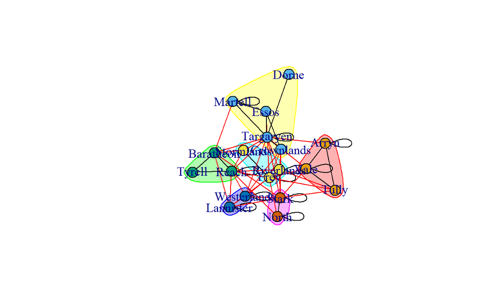

In this partition, most major families are in the same community with their ruling territories, which is very reasonable. The block model clear 0-1 pattern. The within-community density is mostly 1, with two of them are 0.60 and 0.67. Density of ties between communities are relatively low.

The means of centrality scores by community don’t show a clear pattern. Compared with roles, communities focus on the within-group connection. To some extent, each community is a combination of different roles (core + periphery.) Each community has similar means of centrality scores, since they are averages of core roles (high value) and periphery(low value). Roughly, we can say community one has lower influence, which align with conclusio I got in last assignment (about roles.)

##Walktrap Community Detection

```
$`1`
[1] "Arryn"      "Tully"      "Vale"       "Stormlands" "Riverlands"
[6] "Frey"

$`2`
[1] "Martell"    "Crownlands" "Essos"      "Targaryen"  "Dorne"

$`3`
[1] "Baratheon" "Reach"     "Tyrell"

$`4`
[1] "Stark" "North"

$`5`
[1] "Lannister"   "Westerlands"
```

```
        Block 1 Block 2 Block 3 Block 4 Block 5
Block 1    0.53    0.23    0.22    0.33    0.17
Block 2    0.23    0.60    0.20    0.20    0.20
Block 3    0.22    0.20    1.00    0.33    0.50
Block 4    0.33    0.20    0.33    1.00    0.50
Block 5    0.17    0.20    0.50    0.50    1.00
```

```
     comm.wt degree degree.wt bonpow betweenness close constraint
[1,]       1    5.5        23  -1.31         4.5  0.58       0.41
[2,]       2    5.2        22  -0.79         9.3  0.57       0.62
[3,]       3    6.0        22  -0.96         8.9  0.59       0.45
[4,]       4    6.0        36  -0.29         6.9  0.59       0.53
[5,]       5    5.5        25  -0.15         1.4  0.58       0.57
     eigen eigen.rc eigen.dc role_cmpl role_avg role_sing role_wrd
[1,]  0.22    0.047     0.17       1.5      1.3       1.3      2.2
[2,]  0.20    0.041     0.16       2.2      1.6       1.6      3.2
[3,]  0.22    0.039     0.18       2.3      1.7       1.0      2.3
[4,]  0.24    0.114     0.12       2.5      2.0       1.5      3.5
[5,]  0.25    0.095     0.16       1.5      1.0       1.0      3.0
     comm.fg n
[1,]     2.5 6
[2,]     2.0 5
[3,]     3.0 3
[4,]     6.0 2
[5,]     5.0 2
```

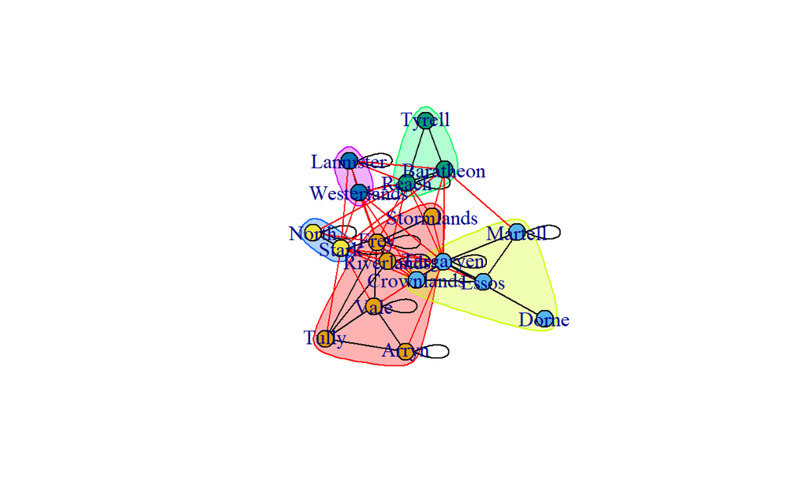

Similarly, communities partitioned by Walktrap algorithm also show (roughly) major family + ruling territory pattern. The difference is, that community 1 & 4 are combined together.

##Leading Label Propagation Community Detection

```
$`1`
[1] "Arryn" "Vale"

$`2`
[1] "Tully"      "Stormlands" "Riverlands" "Frey"

$`3`
[1] "Baratheon" "Reach"     "Tyrell"

$`4`
[1] "Lannister"   "Westerlands"

$`5`
[1] "Martell"    "Crownlands" "Essos"      "Targaryen"  "Dorne"

$`6`
[1] "Stark" "North"
```

```
        Block 1 Block 2 Block 3 Block 4 Block 5 Block 6
Block 1    1.00    0.38    0.00    0.00    0.20    0.25
Block 2    0.38    0.67    0.33    0.25    0.25    0.38
Block 3    0.00    0.33    1.00    0.50    0.20    0.33
Block 4    0.00    0.25    0.50    1.00    0.20    0.50
Block 5    0.20    0.25    0.20    0.20    0.60    0.20
Block 6    0.25    0.38    0.33    0.50    0.20    1.00
```

```
     comm.lab degree degree.wt bonpow betweenness close constraint
[1,]        1    4.0        22  -1.10         1.6  0.53       0.44
[2,]        2    6.2        24  -1.42         5.9  0.60       0.40
[3,]        3    6.0        22  -0.96         8.9  0.59       0.45
[4,]        4    5.5        25  -0.15         1.4  0.58       0.57
[5,]        5    5.2        22  -0.79         9.3  0.57       0.62
[6,]        6    6.0        36  -0.29         6.9  0.59       0.53
     eigen eigen.rc eigen.dc role_cmpl role_avg role_sing role_wrd
[1,]  0.16    0.024     0.13       1.0      1.0       1.0      1.0
[2,]  0.25    0.059     0.19       1.8      1.5       1.5      2.8
[3,]  0.22    0.039     0.18       2.3      1.7       1.0      2.3
[4,]  0.25    0.095     0.16       1.5      1.0       1.0      3.0
[5,]  0.20    0.041     0.16       2.2      1.6       1.6      3.2
[6,]  0.24    0.114     0.12       2.5      2.0       1.5      3.5
     comm.fg comm.wt n
[1,]     1.0       1 2
[2,]     3.2       1 4
[3,]     3.0       3 3
[4,]     5.0       5 2
[5,]     2.0       2 5
[6,]     6.0       4 2
```

[figure not shown]

##Edge Betweenness Community Detection

```
$`1`
[1] "Arryn" "Vale"

$`2`
[1] "Tully"      "Stormlands" "Riverlands" "Frey"

$`3`
[1] "Baratheon" "Reach"     "Tyrell"

$`4`
[1] "Lannister"   "Westerlands"

$`5`
[1] "Martell"    "Crownlands" "Essos"      "Targaryen"  "Dorne"

$`6`
[1] "Stark" "North"
```

```
        Block 1 Block 2 Block 3 Block 4 Block 5 Block 6
Block 1    1.00    0.38    0.00    0.00    0.20    0.25
Block 2    0.38    0.67    0.33    0.25    0.25    0.38
Block 3    0.00    0.33    1.00    0.50    0.20    0.33
Block 4    0.00    0.25    0.50    1.00    0.20    0.50
Block 5    0.20    0.25    0.20    0.20    0.60    0.20
Block 6    0.25    0.38    0.33    0.50    0.20    1.00
```

```
     comm.edge degree degree.wt bonpow betweenness close constraint
[1,]         1    4.0        22  -1.10         1.6  0.53       0.44
[2,]         2    6.2        24  -1.42         5.9  0.60       0.40
[3,]         3    6.0        22  -0.96         8.9  0.59       0.45
[4,]         4    5.5        25  -0.15         1.4  0.58       0.57
[5,]         5    5.2        22  -0.79         9.3  0.57       0.62
[6,]         6    6.0        36  -0.29         6.9  0.59       0.53
     eigen eigen.rc eigen.dc role_cmpl role_avg role_sing role_wrd
[1,]  0.16    0.024     0.13       1.0      1.0       1.0      1.0
[2,]  0.25    0.059     0.19       1.8      1.5       1.5      2.8
[3,]  0.22    0.039     0.18       2.3      1.7       1.0      2.3
[4,]  0.25    0.095     0.16       1.5      1.0       1.0      3.0
[5,]  0.20    0.041     0.16       2.2      1.6       1.6      3.2
[6,]  0.24    0.114     0.12       2.5      2.0       1.5      3.5
     comm.fg comm.wt comm.lab n
[1,]     1.0       1        1 2
[2,]     3.2       1        2 4
[3,]     3.0       3        3 3
[4,]     5.0       5        4 2
[5,]     2.0       2        5 5
[6,]     6.0       4        6 2
```

[figure not shown]

Edge betweenness algorithm gives very similar results. The only difference is that the Tully family is divided into Frey’s community.

##Eigenvector Community Detection

```
$`1`
[1] "Arryn"      "Baratheon"  "Martell"    "Stormlands" "Crownlands"
[6] "Essos"      "Targaryen"  "Dorne"

$`2`
[1] "Tully"      "Vale"       "Riverlands" "Frey"

$`3`
[1] "Reach"

$`4`
[1] "Stark" "North"

$`5`
[1] "Lannister"   "Westerlands"

$`6`
[1] "Tyrell"
```

```
        Block 1 Block 2 Block 3 Block 4 Block 5 Block 6
Block 1    0.39    0.25    0.38    0.19    0.19    0.12
Block 2    0.25    0.83    0.50    0.50    0.25    0.00
Block 3    0.38    0.50     NaN    0.50    1.00    1.00
Block 4    0.19    0.50    0.50    1.00    0.50    0.00
Block 5    0.19    0.25    1.00    0.50    1.00    0.00
Block 6    0.12    0.00    1.00    0.00    0.00     NaN
```

```
     comm.eigen degree degree.wt bonpow betweenness close constraint
[1,]          1    5.0        18  -0.97         7.4  0.57       0.55
[2,]          2    6.5        30  -1.20         6.4  0.60       0.38
[3,]          3    9.0        46  -1.44        15.8  0.68       0.32
[4,]          4    6.0        36  -0.29         6.9  0.59       0.53
[5,]          5    5.5        25  -0.15         1.4  0.58       0.57
[6,]          6    2.0        11  -0.69         0.0  0.45       0.66
     eigen eigen.rc eigen.dc role_cmpl role_avg role_sing role_wrd
[1,] 0.192    0.033    0.159       2.0      1.5       1.4      2.8
[2,] 0.249    0.062    0.186       1.5      1.5       1.5      2.2
[3,] 0.323    0.065    0.258       3.0      2.0       1.0      2.0
[4,] 0.238    0.114    0.123       2.5      2.0       1.5      3.5
[5,] 0.251    0.095    0.156       1.5      1.0       1.0      3.0
[6,] 0.085    0.030    0.055       2.0      1.0       1.0      3.0
     comm.fg comm.wt comm.lab comm.edge n
[1,]     2.2     1.9      3.9       3.9 8
[2,]     2.5     1.0      1.8       1.8 4
[3,]     3.0     3.0      3.0       3.0 1
[4,]     6.0     4.0      6.0       6.0 2
[5,]     5.0     5.0      4.0       4.0 2
[6,]     3.0     3.0      3.0       3.0 1
```

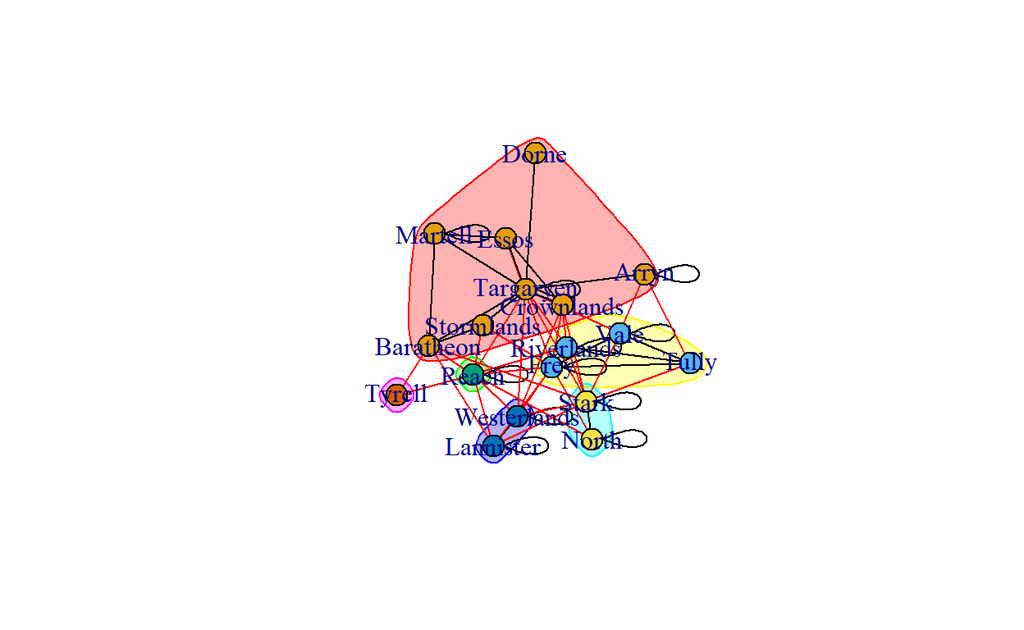

Eigenvector algorithm gives quite a different result, which seems not to make sense according to the novel. The within-community density is not as high, and have some 1-value for between communities density.

##Spinglass Community Detection

```
$`1`
[1] "Baratheon" "Reach"     "Tyrell"

$`2`
[1] "Stark" "North"

$`3`
[1] "Arryn"      "Tully"      "Vale"       "Stormlands" "Riverlands"
[6] "Frey"

$`4`
[1] "Lannister"   "Westerlands"

$`5`
[1] "Martell"    "Crownlands" "Essos"      "Targaryen"  "Dorne"
```

```
        Block 1 Block 2 Block 3 Block 4 Block 5
Block 1    1.00    0.33    0.22    0.50    0.20
Block 2    0.33    1.00    0.33    0.50    0.20
Block 3    0.22    0.33    0.53    0.17    0.23
Block 4    0.50    0.50    0.17    1.00    0.20
Block 5    0.20    0.20    0.23    0.20    0.60
```

```
     comm.spin degree degree.wt bonpow betweenness close constraint
[1,]         1    6.0        22  -0.96         8.9  0.59       0.45
[2,]         2    6.0        36  -0.29         6.9  0.59       0.53
[3,]         3    5.5        23  -1.31         4.5  0.58       0.41
[4,]         4    5.5        25  -0.15         1.4  0.58       0.57
[5,]         5    5.2        22  -0.79         9.3  0.57       0.62
     eigen eigen.rc eigen.dc role_cmpl role_avg role_sing role_wrd
[1,]  0.22    0.039     0.18       2.3      1.7       1.0      2.3
[2,]  0.24    0.114     0.12       2.5      2.0       1.5      3.5
[3,]  0.22    0.047     0.17       1.5      1.3       1.3      2.2
[4,]  0.25    0.095     0.16       1.5      1.0       1.0      3.0
[5,]  0.20    0.041     0.16       2.2      1.6       1.6      3.2
     comm.fg comm.wt comm.lab comm.edge comm.eigen n
[1,]     3.0       3      3.0       3.0        3.3 3
[2,]     6.0       4      6.0       6.0        4.0 2
[3,]     2.5       1      1.7       1.7        1.7 6
[4,]     5.0       5      4.0       4.0        5.0 2
[5,]     2.0       2      5.0       5.0        1.0 5
```

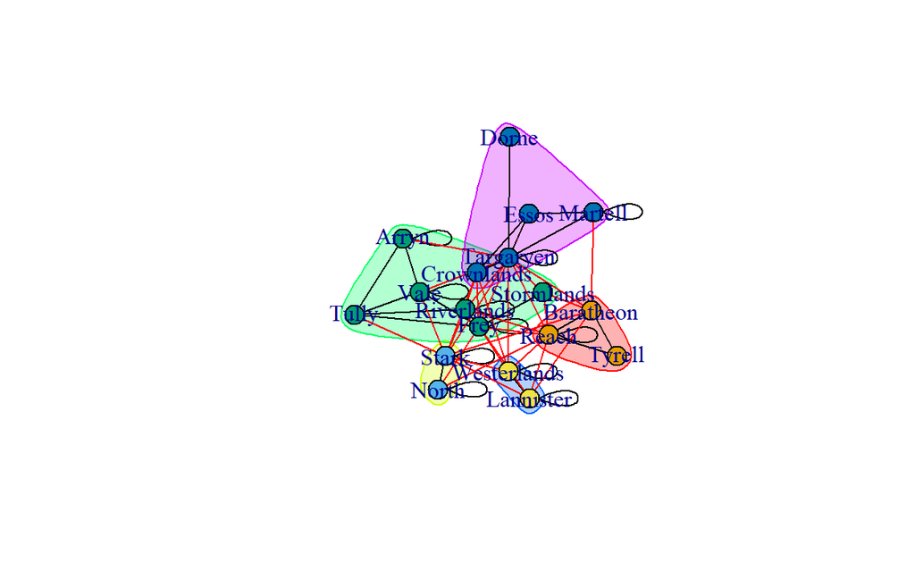

Spinglass algorithm gives the same result with walktrap one.

##Compare Community Partitions

```
fastgreedy   walktrap      label       edge      eigen       spin
 0.5173683  0.3289444  0.5149705  0.5149705  0.4572361  0.0744876
```

```
    alg.a   alg.b          meth    result
1 comm.fg comm.wt            vi 0.2310491
2 comm.fg comm.wt           nmi 0.9288836
3 comm.fg comm.wt    split.join 3.0000000
4 comm.fg comm.wt          rand 0.9411765
5 comm.fg comm.wt adjusted.rand 0.7895461
```

```
    alg.a    alg.b          meth    result
1 comm.fg comm.lab            vi 0.2310491
2 comm.fg comm.lab           nmi 0.9332432
3 comm.fg comm.lab    split.join 2.0000000
4 comm.fg comm.lab          rand 0.9673203
5 comm.fg comm.lab adjusted.rand 0.8647215
```

```
    alg.a     alg.b          meth    result
1 comm.fg comm.edge            vi 0.2310491
2 comm.fg comm.edge           nmi 0.9332432
3 comm.fg comm.edge    split.join 2.0000000
4 comm.fg comm.edge          rand 0.9673203
5 comm.fg comm.edge adjusted.rand 0.8647215
```

```
    alg.a      alg.b          meth    result
1 comm.fg comm.eigen            vi 1.0264363
2 comm.fg comm.eigen           nmi 0.6835936
3 comm.fg comm.eigen    split.join 9.0000000
4 comm.fg comm.eigen          rand 0.8104575
5 comm.fg comm.eigen adjusted.rand 0.3845194
```

```
    alg.a     alg.b          meth    result
1 comm.fg comm.spin            vi 0.2310491
2 comm.fg comm.spin           nmi 0.9288836
3 comm.fg comm.spin    split.join 3.0000000
4 comm.fg comm.spin          rand 0.9411765
5 comm.fg comm.spin adjusted.rand 0.7895461
```

(Can’t understand why spinglass algorithm get such a low modularity score, since it has exactly the same partition with walktrap algorithm.)